# UINMF integration of Dual-omics data

April Kriebel and Joshua Welch

12/03/2021

# Data integration

Here we integrate the scATAC and scRNA reads from the dual-omics dataset SNARE-seq as an illustration of how UINMF can be used to integrate cross-modality data.

```r
install.packages('devtools')
library(devtools)
install_github('welch-lab/liger')
library(rliger)
library(Seurat)
library(stringr)
```

## Step 1: Download the data

First, read in your datasets. For this tutorial, we will use three matrices, which can all be downloaded at https://www.dropbox.com/sh/y9kjoum8u469nj1/AADik2b2-Qo3os2QSWXdIAbna?dl=0 .

The transcriptomic measures (SNAREseq_RNA.RDS) is the SNARE-seq scRNA dataset (31,367 genes by 10,309 cells).

For the shared epigenomic features (SNARE_seq_shared_chromatin_features.RDS), we create a gene-centric matrix, such that we sum of the number of accessibiltiy peaks that occur over the gene body and promoter regions for each gene. For a detailed walkthough of how to generate such a matrix, please see our ’Integrating scRNA and scATAC data vignette ( http://htmlpreview.github.io/?https://github.com/welch-lab/liger/blob/master/vignettes/Integrating_scRNA_and_scATAC_data.html ). The resulting matrix of gene-centric chromatin accessibility is 22,379 genes by 10,309 cells

For the unshared epigenomic features, we binned the genome into bins of 100,000 bp, and summed the number of peaks occuring in each bin. We then filtered this matrix for all bins that overlapped with ENCODE Blacklist regions, ,genes, and promoters. Our filtered matrix (SNARE_seq_unshared_chromatin_features.RDS) is 10,309 cells by 7,437 bins.

```r
rna = readRDS("SNAREseq_RNA.RDS")
shared_atac = readRDS("SNARE_seqvig/SNAREseq_chromatin_accessibility_shared.RDS")
unshared_atac = readRDS("SNARE_seq_unshared_chromatin_features.RDS")
```

## Step 2: Selecting the unshared features

When selecting unshared features for the UINMF integration, it is critical to consider the type of data you are working with. For unshared features that gene-centric, the user should follow the feature selection process outlined in the ‘Integrating unshared features with UINMF’ tutorial ( http://htmlpreview.github.io/?https://github.com/welch-lab/liger/blob/master/vignettes/UINMF_vignette.html ). However, when dealing with features that are not gene-centric (as is the case with our binned intergenic peak counts), we must select the most variable features using an appropriate method. Here, we opt to use Seurat’s `FindVariableFeatures` function. First, we normalize the unshared features:

```r
liger <- createLiger(list(peaks = unshared_atac))
liger <- normalize(liger)
norm <- liger@norm.data$peaks
```

Then we select the top 2,000 variable features:

```r
se = CreateSeuratObject(norm)
vars_2000 <- FindVariableFeatures(se, selection.method = "vst", nfeatures = 2000)
top2000 <- head(VariableFeatures(vars_2000),2000)
top2000_feats <-  norm[top2000,]
```

Then we scale, but do not center the unshared features

```r
liger <- selectGenes(liger)
liger@var.genes <- top2000
liger <- scaleNotCenter(liger)
unshared_feats = liger@scale.data$peaks
```

# Step 3: Preprocessing and normalization

Create a LIGER object and normalize the shared data.

```r
liger <- createLiger(list(rna = rna, atac = shared_atac))
liger <- normalize(liger)
```

Note that when we select the variable genes between the shared features, we use the RNA dataset to select variable shared features.

```r
liger <- selectGenes(liger, var.thresh = 0.1, datasets.use =1 , unshared = TRUE,  unshared.datasets = list(2), unshared.thresh= 0.2)
```

```
## [1] "Selected 11 unshared features from atac Dataset"
```

Scale the data.

```r
liger <- scaleNotCenter(liger)
```

Add the unshared features that have been properly selected, such that they are added as a genes by cells matrix.

```r
peak_names <- rownames(unshared_feats)
liger@var.unshared.features[[2]] = peak_names
liger@scale.unshared.data[[2]] = t(unshared_feats)
```

# Step 4: Joint Matrix Factorization

To factorize the datasets and include the unshared datasets, set the use.unshared parameter to TRUE.

```r
liger <- optimizeALS(liger, k=30, use.unshared = TRUE, max_iters =30,thresh=1e-10)
```

```
## [1] "Performing Factorization using UINMF and unshared features"
## [1] "Processing"
##
## Current seed  1  current objective  67419243
## Best results with seed 1.
```

# Step 5: Quantile Normalization and Joint Clustering

After factorization, the resulting Liger object can be used in all downstream LIGER functions without adjustment. The default reference dataset for quantile normalization is the larger dataset, but the user should select the higher quality dataset as the reference dataset, even if it is the smaller dataset.

```r
liger <- quantile_norm(liger)
liger <- louvainCluster(liger)
```

```
## Louvain Clustering on quantile normalized cell factor loadings.
```

# Step 6: Visualizations and Downstream processing

```r
liger <- runUMAP(liger)
```

Next, we can visualize our returned factorized object by dataset to check the alignment between datasets, as well as by cluster determined in the factorization.

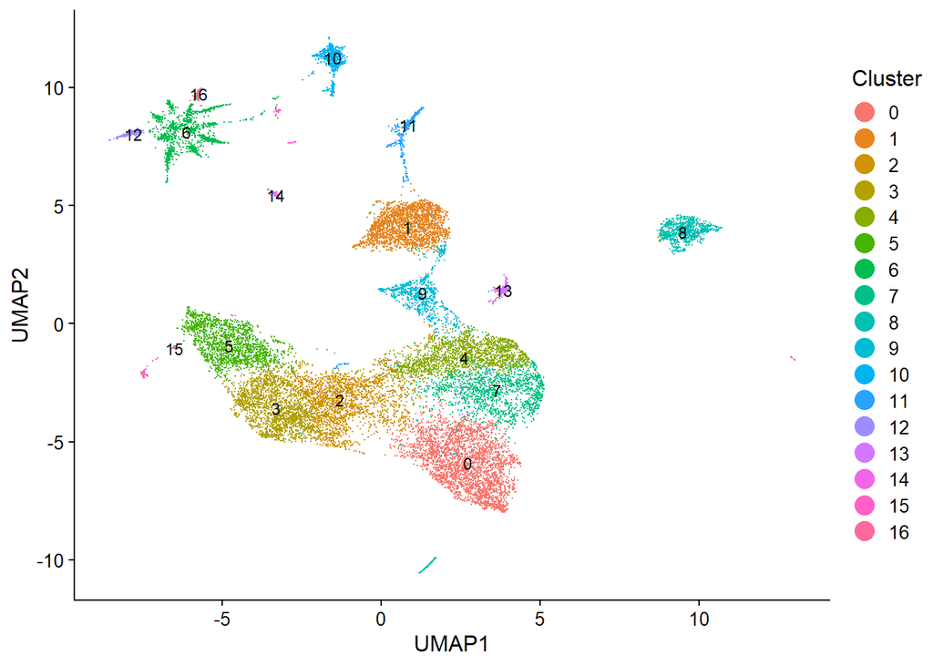

```r
umap_plots <-plotByDatasetAndCluster(liger, axis.labels = c("UMAP1","UMAP2"), return.plots = TRUE)
umap_plots[[2]]
```

We can quantify the alignment between the two dataset with the `calcAlignment` function.

```r
calcAlignment(liger)
```

```
## [1] 0.8300368
```